# Using SARIMA Models to Forecast Ontario Retail Food Prices Based on Jan 2017 - Oct 2022 Data

Alice Huang

20/12/2022

# Analysis and Forecasting of strawberry Prices using SARIMA Model

The prices of the strawberries in the dataset are for 454 g of strawberries. Most supermarket chains sell strawberries in clear plastic boxes which contain 454 grams of strawberries each, so this corresponds to the most common unit that Ontario shoppers will buy strawberries in.

## Summary Plots for Strawberry Prices

The monthly strawberry prices show an increasing trend over time. The monthly strawberry prices appear to be seasonal, with a period of 12 months. Many strawberries in Ontario supermarkets come from the brand Driscoll’s, which grows strawberries in California. According to the US Department of Agriculture, the peak growing season for strawberries in California is around April-November. The seasonality is consistent with strawberry growing season. Generally, strawberries are only in season during the summer each year. During the winter months, when the strawberries are not in season, the prices are higher. During the summer months, when the strawberries are in season, the prices are lower.

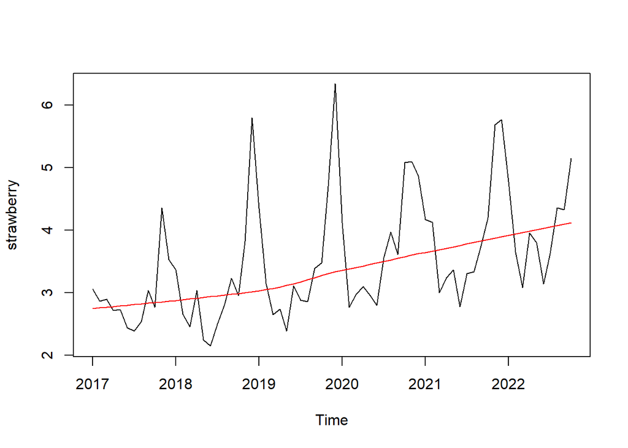

```r
plot.ts(strawberry)
lines(lowess(strawberry), col="red")
```

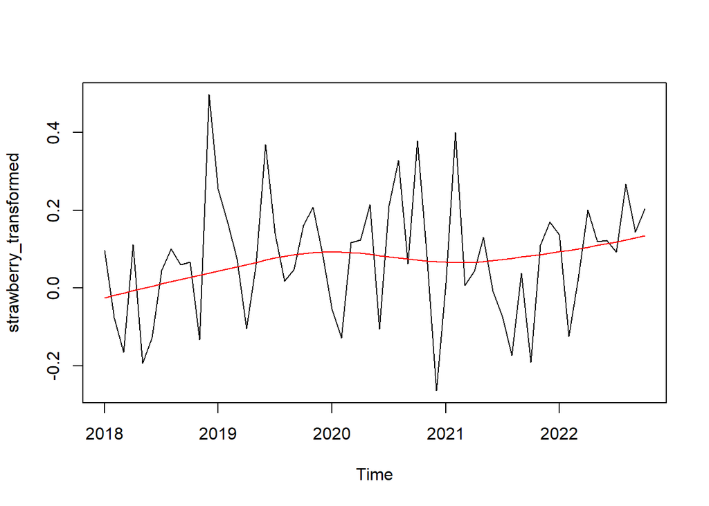

```r
strawberry_transformed <- diff(log(strawberry), lag=12)
plot.ts(strawberry_transformed)
lines(lowess(strawberry_transformed), col="red")
```

```r
adf.test(strawberry_transformed)
```

```
##
##  Augmented Dickey-Fuller Test
##
## data:  strawberry_transformed
## Dickey-Fuller = -3.2541, Lag order = 3, p-value = 0.08766
## alternative hypothesis: stationary
```

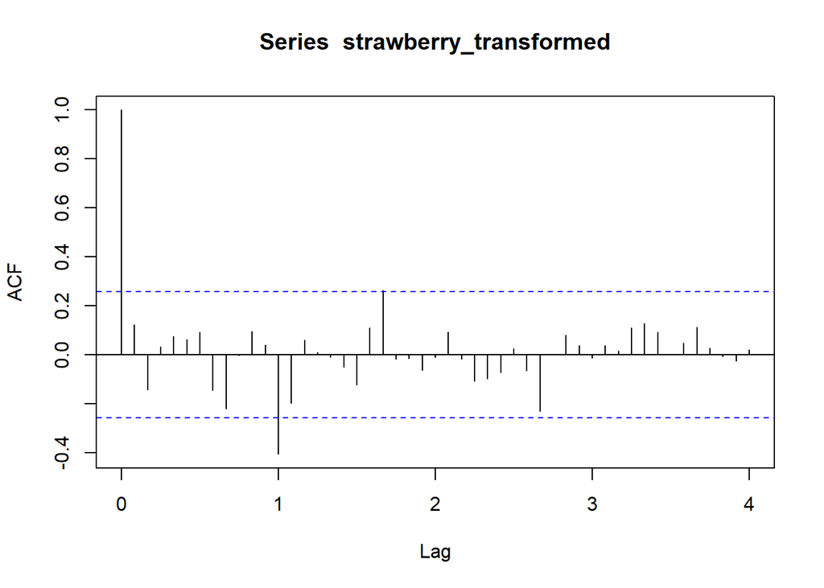

```r
acf(strawberry_transformed, lag.max = 48)
```

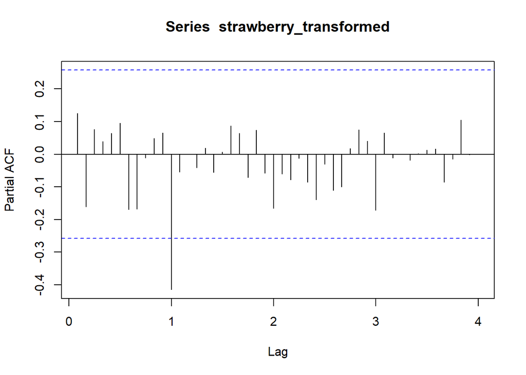

```r
pacf(strawberry_transformed, lag.max = 48)
```

## SARIMA model for strawberry prices

We use auto.arima() to find the best SARIMA model for the log of the strawberry prices. It turns out that a ARIMA$(0,0,0)\times(1,1,0)_{12}$ with drift is the best.

```r
log_strawberry_sarima <- auto.arima(log(strawberry))
log_strawberry_sarima
```

```
## Series: log(strawberry)
## ARIMA(0,0,0)(1,1,0)[12] with drift
##
## Coefficients:
##          sar1   drift
##       -0.4939  0.0064
## s.e.   0.1184  0.0011
##
## sigma^2 = 0.01913:  log likelihood = 31.78
## AIC=-57.56   AICc=-57.12   BIC=-51.38
```

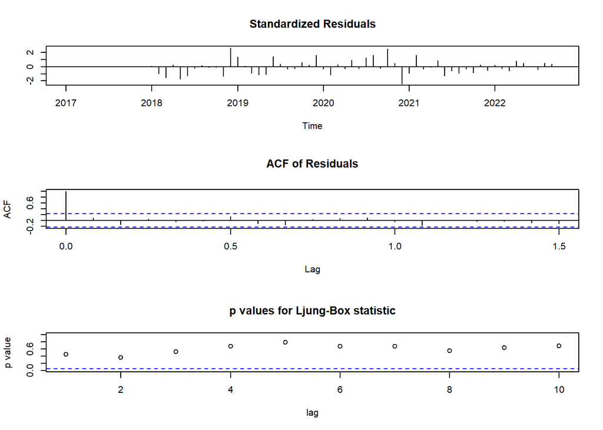

```r
tsdiag(log_strawberry_sarima)
```

The residuals appear to be white noise, because the ACF of the residuals has no spikes outside the trivial spike at lag 0. Ljung-Box test tests the null hypothesis that the residuals are white noise against the alternative hypothesis that the residuals are not white noise. Since the p-values for Ljung-Box statistic are higher than 0.05, we do not reject the null hypothesis that the residuals are white noise.

## Forecasted strawberry prices using SARIMA

```r
forecast(log_strawberry_sarima, 14) -> forecast_log_strawberrydf
strawberry_forecasts <- cbind(exp(forecast_log_strawberrydf$mean), exp(forecast_log_strawberrydf$lower[,2]), exp(forecast_log_strawberrydf$upper[,2]))
colnames(strawberry_forecasts) <- c("Forecasted Strawberry Price", "Lower bound 95% CI", "Upper bound 95% CI")
strawberry_forecasts
```

```
##          Forecasted Strawberry Price Lower bound 95% CI Upper bound 95% CI
## Nov 2022                    6.040583           4.606264           7.921527
## Dec 2022                    5.946344           4.534402           7.797943
## Jan 2023                    5.007162           3.818226           6.566314
## Feb 2023                    4.347493           3.315193           5.701234
## Mar 2023                    3.406844           2.597899           4.467683
## Apr 2023                    4.018838           3.064576           5.270241
## May 2023                    4.013032           3.060149           5.262628
## Jun 2023                    3.313276           2.526548           4.344978
## Jul 2023                    3.886505           2.963665           5.096702
## Aug 2023                    4.283237           3.266195           5.616970
## Sep 2023                    4.519482           3.446344           5.926778
## Oct 2023                    5.218159           3.979122           6.843012
## Nov 2023                    6.572052           4.850098           8.905358
## Dec 2023                    6.565069           4.844945           8.895897
```